# Assumptions of Linear Models & Data Transformations

Jamie Reilly, Ph.D.

2020-06-01

Libraries

```r
library(reshape2)
library(tidyverse)
library(stats)
library(pastecs)
library(moments)  #gives skewness and kurtosis
library(car)
library(psych)
library(outliers)
jamie.theme <- theme_bw() + theme(axis.line = element_line(colour = "black"),
    panel.grid.minor = element_blank(), panel.grid.major = element_blank(),
    panel.border = element_blank(), panel.background = element_blank(), legend.title = element_blank())  #custom graphics theme for ggplot2
```

We’ll first read in the data. These data reflect an abbreviated version of the Lancaster Sensorimotor norms by Lynott et al 2019. The Lancaster norms reflect subjective crowdsourced ratings of the salience of many English words on vision, audition, olfaction, etc.

```r
Lancaster <- read.csv("LancasterShort.csv", header=T)
str(Lancaster)
```

```
## 'data.frame':    39705 obs. of  14 variables:
##  $ Word                 : Factor w/ 39705 levels "AARDVARK","ABACK",..: 1 2 3 4 5 6 7 8 9 10 ...
##  $ Auditory             : num  1.625 1.294 1.556 0.941 1.444 ...
##  $ Gustatory            : num  0.5625 0.0588 0.1667 0.1176 0 ...
##  $ Haptic               : num  1.625 0.2941 3.7222 0.2941 0.0556 ...
##  $ Interoceptive        : num  0.0625 1.3529 0.2778 2.1176 1.6667 ...
##  $ Olfactory            : num  1.25 0 0.1111 0.0588 0 ...
##  $ Visual               : num  4.12 2.82 3.94 2.18 2.78 ...
##  $ Foot_leg             : num  0.176 0 0 1.1 1.316 ...
##  $ Hand_arm             : num  0.706 0 2.474 0.7 1.053 ...
##  $ Head                 : num  2.24 3.27 2.63 2.45 2.63 ...
##  $ Mouth                : num  0.0588 0.3636 0.1053 0.55 0.8947 ...
##  $ Torso                : num  0.0588 0.1818 0 0.9 0.7895 ...
##  $ Dominant.sensorimotor: Factor w/ 11 levels "Auditory","Foot_leg",..: 11 6 11 6 11 11 11 11 11 11 ...
##  $ Mean_age.perceptual  : num  36.1 43.8 36.8 38.9 37.9 ...
```

```r
head(Lancaster, n=10)
```

```
##           Word  Auditory  Gustatory     Haptic Interoceptive  Olfactory
## 1     AARDVARK 1.6250000 0.56250000 1.62500000     0.0625000 1.25000000
## 2        ABACK 1.2941176 0.05882353 0.29411765     1.3529412 0.00000000
## 3       ABACUS 1.5555556 0.16666667 3.72222222     0.2777778 0.11111111
## 4      ABANDON 0.9411765 0.11764706 0.29411765     2.1176471 0.05882353
## 5    ABANDONED 1.4444444 0.00000000 0.05555556     1.6666667 0.00000000
## 6    ABANDONEE 1.9375000 0.00000000 1.37500000     0.5625000 0.25000000
## 7    ABANDONER 0.5714286 0.00000000 0.14285714     1.6428571 0.00000000
## 8  ABANDONMENT 2.1333333 0.06666667 1.20000000     2.9333333 0.06666667
## 9    ABASEMENT 2.8333333 0.16666667 0.66666667     1.2500000 0.16666667
## 10  ABBREVIATE 2.4000000 0.00000000 0.15000000     0.4500000 0.00000000
##      Visual  Foot_leg  Hand_arm     Head      Mouth      Torso
## 1  4.125000 0.1764706 0.7058824 2.235294 0.05882353 0.05882353
## 2  2.823529 0.0000000 0.0000000 3.272727 0.36363636 0.18181818
## 3  3.944444 0.0000000 2.4736842 2.631579 0.10526316 0.00000000
```

[output cut: 18 more lines]

Wrangle the dataframe from wide to long form Let’s melt the dataframe so we can do a bunch of stats at once by factor. We will only use a few columns.

```r
short <- Lancaster %>% select(1:7)
head(short)
```

```
##        Word  Auditory  Gustatory     Haptic Interoceptive  Olfactory   Visual
## 1  AARDVARK 1.6250000 0.56250000 1.62500000     0.0625000 1.25000000 4.125000
## 2     ABACK 1.2941176 0.05882353 0.29411765     1.3529412 0.00000000 2.823529
## 3    ABACUS 1.5555556 0.16666667 3.72222222     0.2777778 0.11111111 3.944444
## 4   ABANDON 0.9411765 0.11764706 0.29411765     2.1176471 0.05882353 2.176471
## 5 ABANDONED 1.4444444 0.00000000 0.05555556     1.6666667 0.00000000 2.777778
## 6 ABANDONEE 1.9375000 0.00000000 1.37500000     0.5625000 0.25000000 3.937500
```

```r
long <- short %>% melt(id.vars=1, measure.vars=2:7, variable.name="modality", value.name="rating")
str(long)
```

```
## 'data.frame':    238230 obs. of  3 variables:
##  $ Word    : Factor w/ 39705 levels "AARDVARK","ABACK",..: 1 2 3 4 5 6 7 8 9 10 ...
##  $ modality: Factor w/ 6 levels "Auditory","Gustatory",..: 1 1 1 1 1 1 1 1 1 1 ...
##  $ rating  : num  1.625 1.294 1.556 0.941 1.444 ...
```

```r
head(long)
```

```
##        Word modality    rating
## 1  AARDVARK Auditory 1.6250000
## 2     ABACK Auditory 1.2941176
## 3    ABACUS Auditory 1.5555556
## 4   ABANDON Auditory 0.9411765
## 5 ABANDONED Auditory 1.4444444
## 6 ABANDONEE Auditory 1.9375000
```

descriptive stats by level of a grouping variable

```r
describeBy(long$rating, long$modality)
```

```
##
##  Descriptive statistics by group
## group: Auditory
##    vars     n mean   sd median trimmed  mad min max range skew kurtosis se
## X1    1 39705 1.51 0.99   1.38    1.43 1.02   0   5     5 0.74     0.21  0
## --------------------------------------------------------
## group: Gustatory
##    vars     n mean  sd median trimmed  mad min max range skew kurtosis se
## X1    1 39705 0.32 0.7   0.12    0.16 0.17   0   5     5 4.21    19.36  0
## --------------------------------------------------------
## group: Haptic
##    vars     n mean   sd median trimmed  mad min  max range skew kurtosis
## X1    1 39705 1.07 0.93   0.77    0.94 0.75   0 4.94  4.94 1.17     0.79
##    se
## X1  0
## --------------------------------------------------------
## group: Interoceptive
##    vars     n mean   sd median trimmed  mad min max range skew kurtosis se
## X1    1 39705 1.03 0.88   0.78     0.9 0.72   0 4.9   4.9 1.32     1.58  0
## --------------------------------------------------------
## group: Olfactory
##    vars     n mean   sd median trimmed  mad min max range skew kurtosis se
## X1    1 39705 0.39 0.62   0.19    0.25 0.28   0   5     5 3.18    12.06  0
## --------------------------------------------------------
## group: Visual
##    vars     n mean  sd median trimmed  mad min max range  skew kurtosis se
## X1    1 39705  2.9 0.9   2.94    2.92 0.98   0   5     5 -0.25    -0.46  0
```

# 1 Assumptions

Parametric model assumptions (see Field et al, Chapter 5)  
1) Normally distributed  
2) Homogeneity of variance across groups  
3) Interval or ratio scale  
4) Independence

Let’s take these one at a time using the Lancaster norms as a test case

## 1.1 Normality

### 1.1.1 Histogram of visual salience across English words

Let’s first visualize the distribution using a histogram and overlay a normal curve over the distribution. To do this, we need to plot density and not frequency. Let’s overlay a normal curve and take a guess. That looks pretty darn normal to me.

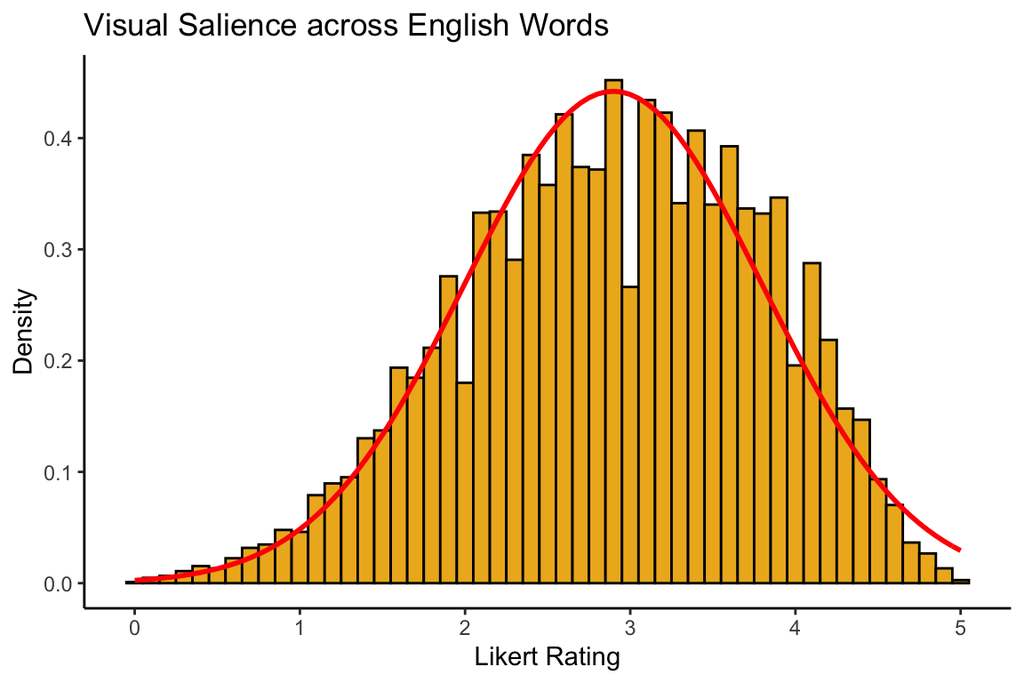

```r
ggplot(Lancaster, aes(x = Visual)) + geom_histogram(aes(y = ..density..),
    colour = "black", fill = "goldenrod2", binwidth = 0.10) + xlab("Likert Rating") +
    ylab("Density") + jamie.theme + ggtitle("Visual Salience across English Words") + stat_function(fun = dnorm, args = list(mean = mean(Lancaster$Visual), sd= sd(Lancaster$Visual)), color="red", size=1)
```

### 1.1.2 QQplot

Let’s run a qqplot on all that visual data

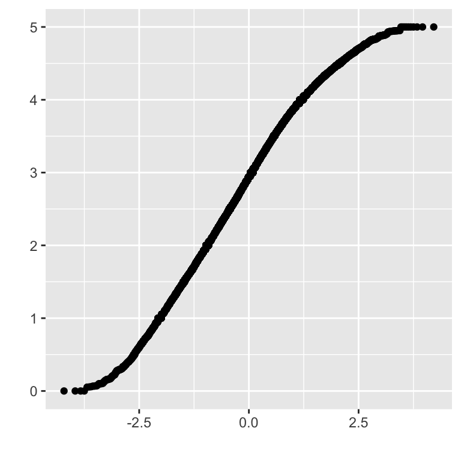

```r
qplot(sample = Lancaster$Visual, stat = "qq")
```

### 1.1.3 Normality statistics (Shapiro Wilk)

Shapiro Wilk Test – null hypothesis is no difference (i.e., normal). It won’t work on large samples (>5k) but let’s try it out on a smaller distribution we know to be normal

```r
bell <- rnorm(5000, 5, 1)  #here's a fake dataset, sampling 5000 random normally distributed numbers with a mean of 5 and an sd=1
shapiro.test(bell)
```

```
##
##  Shapiro-Wilk normality test
##
## data:  bell
## W = 0.99966, p-value = 0.5934
```

### 1.1.4 Histograms of multiple variables at once

We will use the facet wrap function to do this. Use the long form dataframe

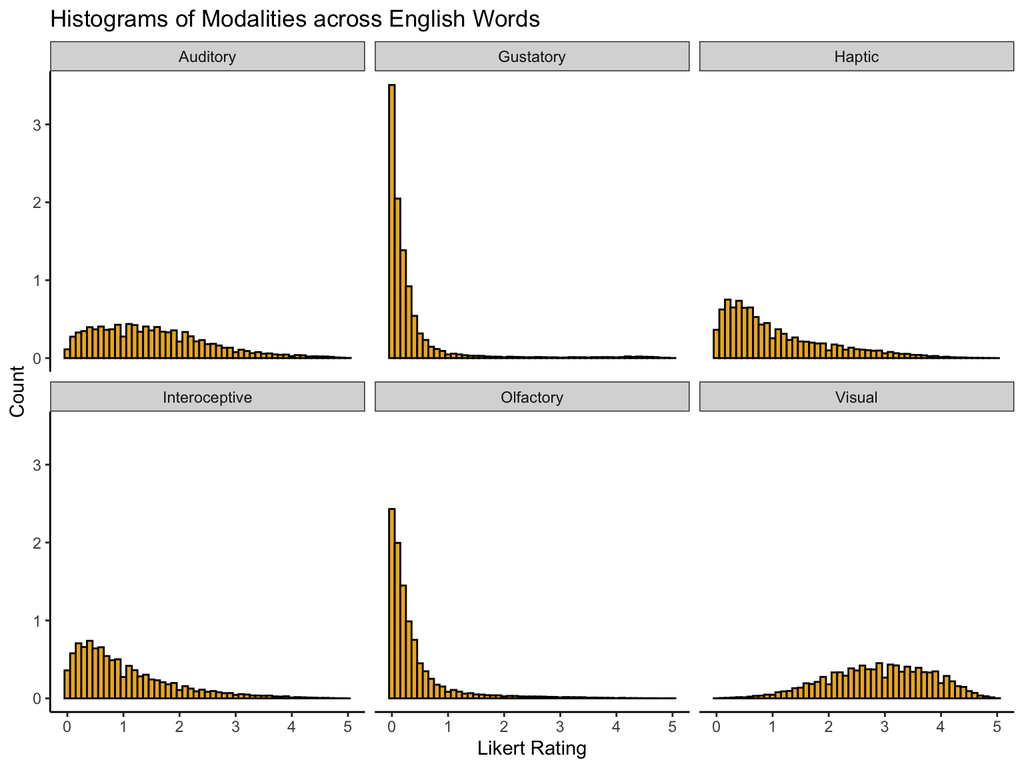

```r
all <- ggplot(long, aes(x = rating), fill=modality) + geom_histogram(aes(y = ..density..),
   binwidth = 0.10, color="black", fill="goldenrod2") + xlab("Likert Rating") +
    ylab("Count") + jamie.theme + ggtitle("Histograms of Modalities across English Words") +  facet_wrap(~modality, nrow=2)
all
```

## 1.2 Equal Variance

### 1.2.1 Boxplot for coarse inspection

All levels of the factor variables should have equal variance  
First let’s coarsely eyeball the variance of the groups by each sensory modality

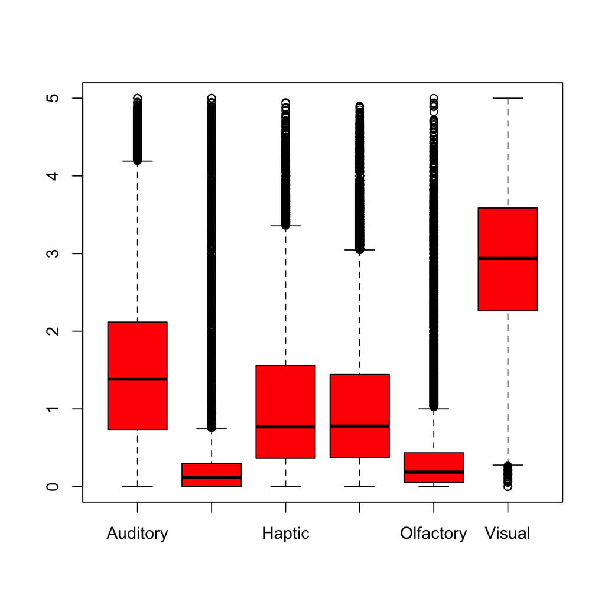

```r
boxplot(long$rating ~ long$modality, col = "red")
```

### 1.2.2 Levene Test

Null hypothesis is the no difference hypothesis

```r
leveneTest(long$rating, long$modality, center = mean)
```

```
## Levene's Test for Homogeneity of Variance (center = mean)
##           Df F value    Pr(>F)
## group      5  4958.3 < 2.2e-16 ***
##       238224
## ---
## Signif. codes:  0 '***' 0.001 '**' 0.01 '*' 0.05 '.' 0.1 ' ' 1
```

## 1.3 Interval or ratio scale

Self explanatory

## 1.4 Independence

Self-explanatory. Each word is its own independent observation in the Lancaster normns. There is no temporal autocorrelation.

# 2 Outliers & Outlier detection

Let’s create a univariate distribution – shoe sizes. 1.5*IQR is a univariate outlier using the boxplot method. the mean method is >2sds

```r
set.seed(129)
shoes <-  data.frame("sizes"=c(sample(12, 20, replace=T), 30), "type"=rep("nike", 21))
head(shoes)
```

```
##   sizes type
## 1     2 nike
## 2     4 nike
## 3     2 nike
## 4     4 nike
## 5     2 nike
## 6     7 nike
```

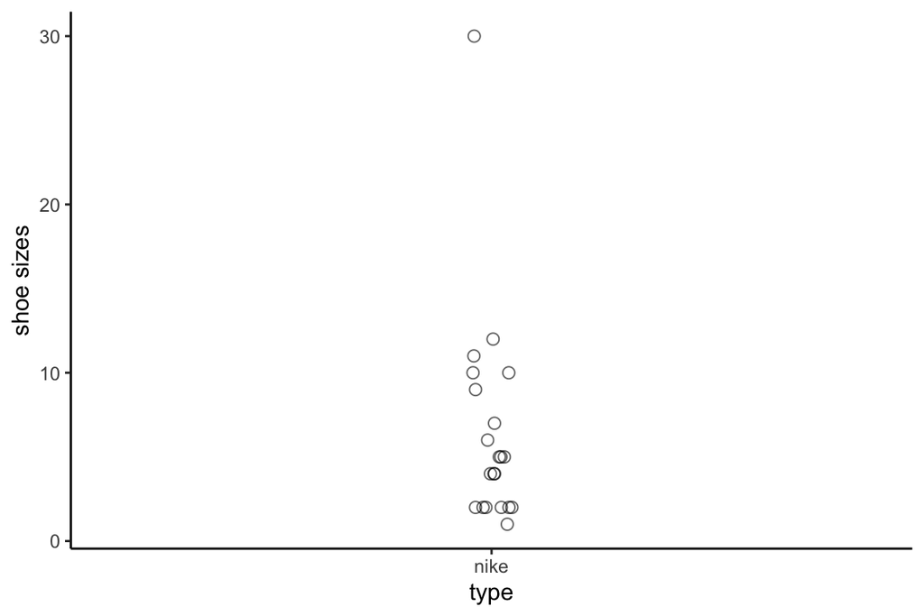

```r
ggplot(shoes, aes(x=type, y=sizes), fill=sizes) + geom_point(shape = 21, color = "black", size = 2.3, alpha = 0.6, position = position_jitter(w = 0.03, h = 0)) + ylab("shoe sizes") + jamie.theme
```

```r
summary(shoes)
```

```
##      sizes          type
##  Min.   : 1.000   nike:21
##  1st Qu.: 2.000
##  Median : 5.000
##  Mean   : 6.429
##  3rd Qu.: 9.000
##  Max.   :30.000
```

```r
shoes.z <- shoes %>% mutate(zsize = scale(shoes$sizes)) #generates a new dataframe with the z-scores for shoe sizes as a new variable you can sort on or filter on
head(shoes.z)
```

```
##   sizes type       zsize
## 1     2 nike -0.69539246
## 2     4 nike -0.38134425
## 3     2 nike -0.69539246
## 4     4 nike -0.38134425
## 5     2 nike -0.69539246
## 6     7 nike  0.08972806
```

## 2.1 Eliminating outliers z>2 (one tailed get rid of big shoes)

We can just throw them out by filtering or applying a simple if then statement

```r
shoes.small <- shoes.z %>% filter(zsize <= 2)  #creates a new dataframe returning only shoe sizes z<2 in the original distribution
summary(shoes.small)
```

```
##      sizes         type          zsize.V1
##  Min.   : 1.00   nike:20   Min.   :-0.8524166
##  1st Qu.: 2.00             1st Qu.:-0.6953925
##  Median : 4.50             Median :-0.3028322
##  Mean   : 5.25             Mean   :-0.1850641
##  3rd Qu.: 7.50             3rd Qu.: 0.1682401
##  Max.   :12.00             Max.   : 0.8748486
```

```r
shoes.mid <- shoes.z %>% filter(zsize <= abs(1))  #creates a new dataframe returning only shoe #sizes within the central range of +/- 1 sd of the mean
shoes.mid
```

```
##    sizes type       zsize
## 1      2 nike -0.69539246
## 2      4 nike -0.38134425
## 3      2 nike -0.69539246
## 4      4 nike -0.38134425
## 5      2 nike -0.69539246
## 6      7 nike  0.08972806
## 7      2 nike -0.69539246
## 8      5 nike -0.22432015
## 9     12 nike  0.87484858
## 10     1 nike -0.85241656
## 11    10 nike  0.56080037
## 12     4 nike -0.38134425
## 13    10 nike  0.56080037
## 14     2 nike -0.69539246
## 15     6 nike -0.06729604
## 16     9 nike  0.40377627
## 17    11 nike  0.71782448
## 18     5 nike -0.22432015
## 19     2 nike -0.69539246
## 20     5 nike -0.22432015
```

# 3 Transformations

Need to be done on all the variables not just one. Let’s look at the olfactory ratings.

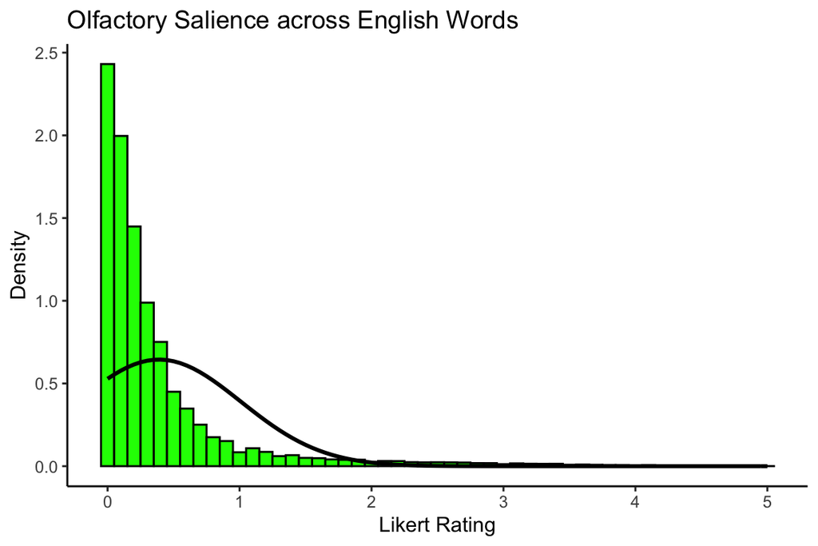

```r
ggplot(Lancaster, aes(x = Olfactory)) + geom_histogram(aes(y = ..density..),
    colour = "black", fill = "green", binwidth = 0.10) + xlab("Likert Rating") +
    ylab("Density") + jamie.theme + ggtitle("Olfactory Salience across English Words") + stat_function(fun = dnorm, args = list(mean = mean(Lancaster$Olfactory), sd= sd(Lancaster$Olfactory)), color="black", size=1)
```

## 3.1 Natural log transform

For illustrative purposes I have created a new dataframe with just smell and visual ratings on English words. This transform is good for positively skewed data – long tail to right. There’s a problem here in that we have some zero observations

```r
brief <- Lancaster %>% select(1,6,7)
length(which(brief$Olfactory==0))  #counts the number of rows with a 0 observation
```

```
## [1] 8993
```

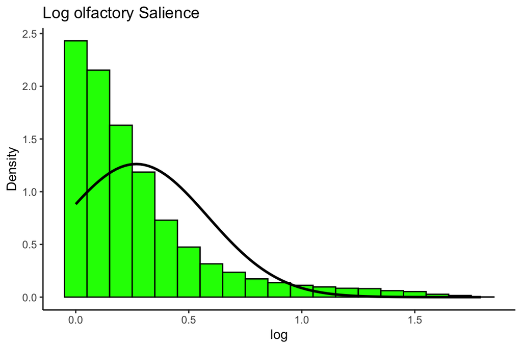

```r
brief$log <- log(brief$Olfactory + 1) #log is natural log, log10 is log base 10, this adds 1 so that there is never a 0 observation
ggplot(brief, aes(x = log)) + geom_histogram(aes(y = ..density..),
    colour = "black", fill = "green", binwidth = 0.10) +
    ylab("Density") + jamie.theme + ggtitle("Log olfactory Salience") + stat_function(fun = dnorm, args = list(mean = mean(brief$log), sd= sd(brief$log)), color="black", size=1)
```

## 3.2 Square root transformation

You don’t have to worry about zeros

```r
brief$sqrt <- sqrt(brief$Olfactory)
head(brief)
```

```
##        Word  Olfactory   Visual        log      sqrt
## 1  AARDVARK 1.25000000 4.125000 0.81093022 1.1180340
## 2     ABACK 0.00000000 2.823529 0.00000000 0.0000000
## 3    ABACUS 0.11111111 3.944444 0.10536052 0.3333333
## 4   ABANDON 0.05882353 2.176471 0.05715841 0.2425356
## 5 ABANDONED 0.00000000 2.777778 0.00000000 0.0000000
## 6 ABANDONEE 0.25000000 3.937500 0.22314355 0.5000000
```

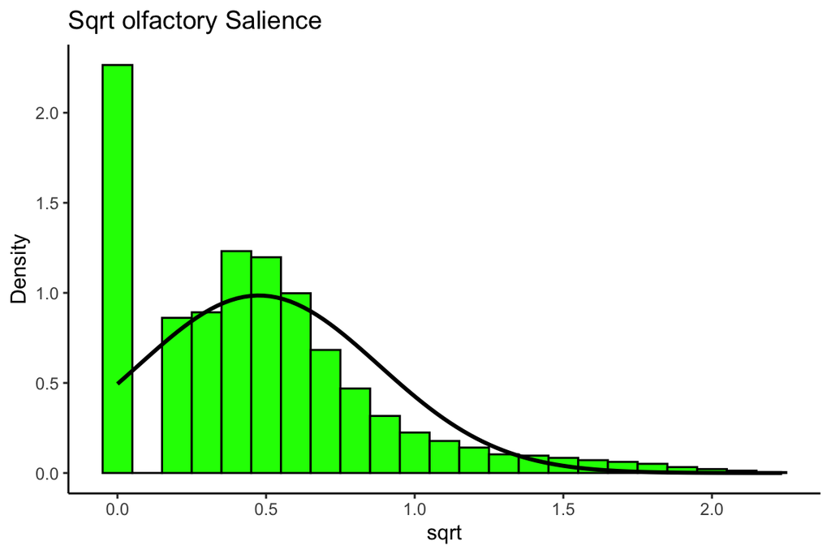

```r
ggplot(brief, aes(x = sqrt)) + geom_histogram(aes(y = ..density..),
    colour = "black", fill = "green", binwidth = 0.10) +
    ylab("Density") + jamie.theme + ggtitle("Sqrt olfactory Salience") + stat_function(fun = dnorm, args = list(mean = mean(brief$sqrt), sd= sd(brief$sqrt)), color="black", size=1)
```

## 3.3 Reciprocal transformation

Doesn’t work when there are zeros in the denominator

```r
brief$recip <- 1/(brief$Olfactory+1)
head(brief)
```

```
##        Word  Olfactory   Visual        log      sqrt     recip
## 1  AARDVARK 1.25000000 4.125000 0.81093022 1.1180340 0.4444444
## 2     ABACK 0.00000000 2.823529 0.00000000 0.0000000 1.0000000
## 3    ABACUS 0.11111111 3.944444 0.10536052 0.3333333 0.9000000
## 4   ABANDON 0.05882353 2.176471 0.05715841 0.2425356 0.9444444
## 5 ABANDONED 0.00000000 2.777778 0.00000000 0.0000000 1.0000000
## 6 ABANDONEE 0.25000000 3.937500 0.22314355 0.5000000 0.8000000
```

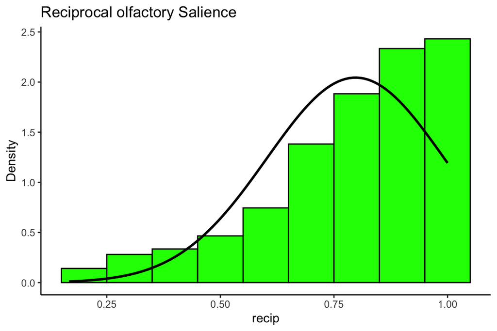

```r
ggplot(brief, aes(x = recip)) + geom_histogram(aes(y = ..density..),
    colour = "black", fill = "green", binwidth = 0.10) +
    ylab("Density") + jamie.theme + ggtitle("Reciprocal olfactory Salience") + stat_function(fun = dnorm, args = list(mean = mean(brief$recip), sd= sd(brief$recip)), color="black", size=1)
```

Questions: /  
1) Do you have to apply the transform uniformly across all variables